# Final_BIO658_Stillman

Anthony Stillman

2025-11-10

# Github Link:

https://github.com/StillCodingBio/Final_BIOS658

# TITLE:

**RNA-seq Data Analysis of Frontal Cortex Samples from Individuals that have had COVID-19.**

# INTRODUCTION:

Severe acute respiratory syndrome coronavirus 2 (SARS-CoV-2), better know as COVID-19, has left a significant mark on the world (Maital (2020)). The World Health Organization (WHO) reports that there have been ~779 million reported cases of COVID-19 as of toward the end of 2025 (WHO (2025)). The initial infection and symptoms of COVID-19 have been a significant health burden by itself, but now there is a lingering affect know as Long COVID. Long COVID is various chronic conditions that affect individuals after they have had COVID-19 (Raveendran AV (2021)). Long COVID is difficult to define due to it not seemingly affecting the same biological systems from person to person (Raveendran AV (2021)). There have been various studies across different biological systems of former COVID-19 patients to better understand Long COVID. A biological system that can be affected by Long COVID is the brain (Reiss AB (2023)). COVID-19 appears to speed up aging in the brain through various mechanisms (Müller L (2024)). This report is interested on taking the RNA-Seq data derived brain tissue samples of people who have had COVID-19 and determining if COVID-19 creates chronic conditions that affect the brain. This report will use data from “Severe COVID-19 is associated with molecular signatures of aging in the human brain” by Maria Mavrikaki, Jonathan D. Lee, Isaac H. Solomon, and Frank J. Slack; the data is composed of individuals that have and have not had COVID-19 across genders and ages (Mavrikaki (2022)).

# METHODS:

## Processing and Analysis Platform.

All the data processing, analysis, and figure creation was done with R and RStudio. Please see the Computational Component section for the library of packages used and how they were used.

## Preprocessing:

**Data:** The data is composed of RNA-sequencing data from frontal cortex samples. The samples were taken from 22 individuals that have had COVID-19 and 23 individuals that have not had COVID-19 (Mavrikaki (2022)). The samples were from individuals of various ages and genders.

**Data retrieval:** The data of interest is cataloged in the GEO database as GSE188847 (https://www.ncbi.nlm.nih.gov/geo/download/?acc=GSE188847&format=file). This package of files were download and untarred with R.

**Data unpacking:** The function “GEOquery::getGEO” was used to retrieve experimental details for GSE188847 and structure it; the phenotype data was then extracted from the getGEO object with “Biobase::pData”. The read counts and abundances were extracted and structured from the GSE188847 file via “tximport” using the salmon format. The phenotype, counts, and abundance data was formatted together into a summarize experiment data format using “SummarizedExperiment”.

**Connect to Ensembl:** useMart was used to link each mRNA transcription ID with their associated ensemble gene ID, gene symbol, biotype, and description.

**Sample Isolation:** The GSE188847 had other experimental groups that were outside our interest. These were removed from the data set. In addition a variable of unaffected (Never had COVID-19) and affected (Has had COVID-19) was added to the data per sample for later use.

**Low gene expression filtering and normalization:** The experimental summary data set was turned into an DGEList object with “edgeR::SE2DGEList”. Duplicated data was removed from the DGEList object via R functions. Genes with low expression were removed from the DGEList object with “edgeR::filterByExpr”. The data was normalized based on library size via “edgeR::normLibSizes”, which uses the TMM normalization method.

## Batch Effect Correction.

The batches of sample processing and reading could not be determined. To remove the batch effect “sva” methods in combination with “limma::removeBatchEffect” were used to remove the batch affect from the data. Past COVID-19 infection, age, and sex were used for the “sva” biological components. The affect of the batch effect correction was visualized by sum of counts per sample, hierarchical clustering on the top 10% most variable genes, PCA plots, and boxplot of log2(expression) between samples; these visualizations were done before and after the batch effect correction.

After the batch effect correction the a multidimensional scaling plot was done to further visualize the relationship between samples and row standard deviations versus row means plot to illustrate the distribution of the data.

## Differential Expression Analysis.

**Design:** The variants for the expression analysis were gender as an factor, age as an continuous factor, and previous COVID-19 infection as a factor.

**Estimated dispersion:** “edgeR::estimateDisp” was used to calculate the dispersion of the data. This was further illustrated via BCV plot (“edgeR::plotBCV”).

**Modeling:** A general linear model was fitted onto the data with “edgeR::glmFit” based on the design. A likelihood-ratio test was run on the fitted model with “edgeR::glmLRT” with previous COVID-19 exposure as the coefficient, revealing up and down regulated genes between the COVID-19 and control groups. The differential expression was visualized with a Mean-Difference Plot (“limma::plotMD”).

**Multiple testing correction methods:** False Discovery Rate (FDR) correction method were used on the data. This method is very effective at adjusting p-values of large number of tests.

## Functional Enrichment Analysis.

Functional enrichment analysis was done with code created by Dr. Mikhail Dozmorov (https://github.com/mdozmorov). The analysis was done on GSEA and over representation analysis using the three gene ontology domains (Biological Process, Molecular Function, Cellular Component (GSEA (2025))) and KEGG pathways (Dozmorov (2025)).

# RESULTS

## Quality Assessment Before SVA.

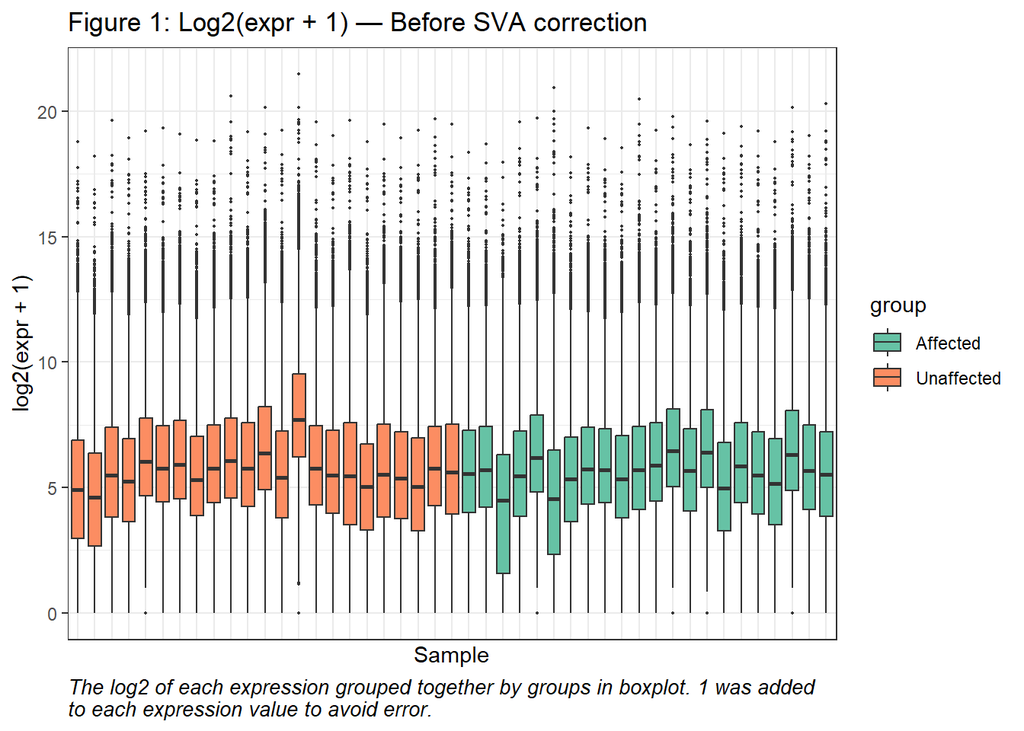

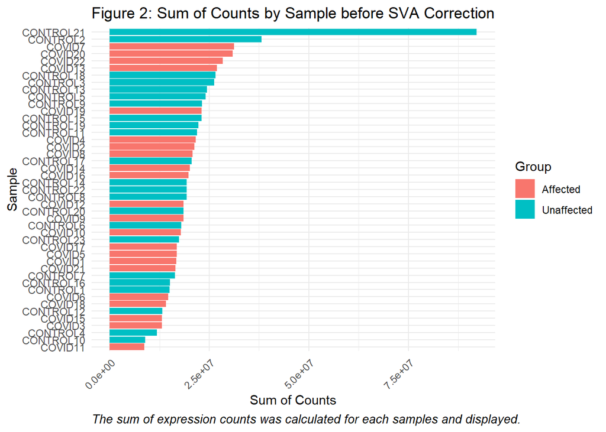

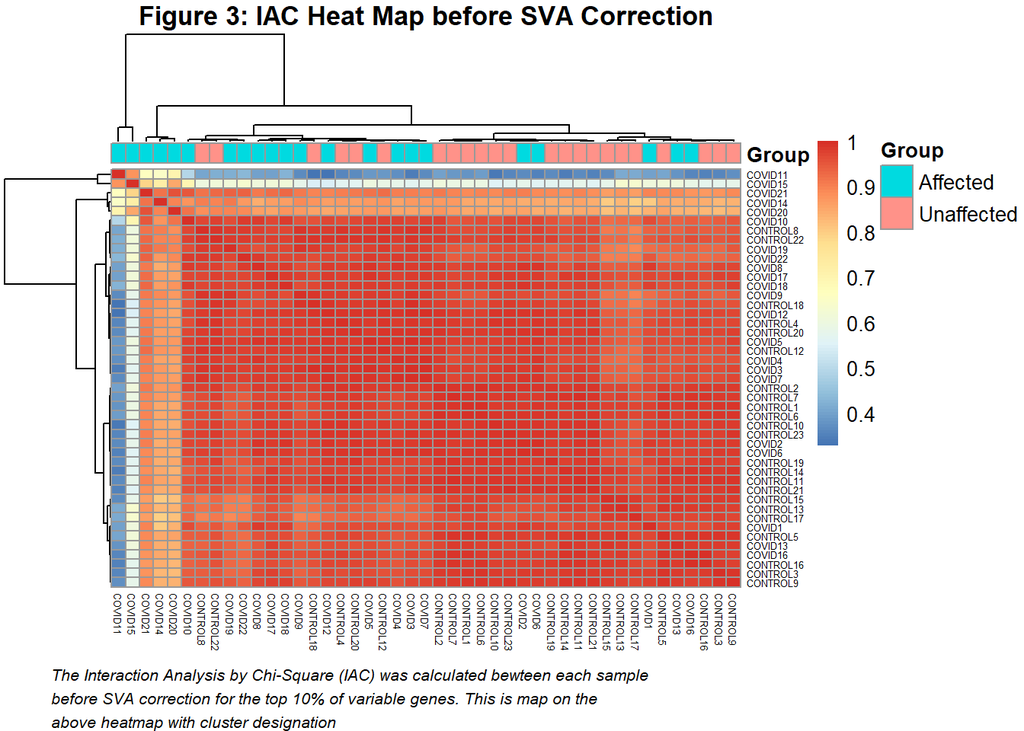

Table 1: Summary of PCA results before SVA correction

|  | PC1 | PC2 | PC3 | PC4 | PC5 |
| --- | --- | --- | --- | --- | --- |
| Standard deviation | 47.788 | 31.263 | 20.597 | 17.622 | 16.393 |
| Proportion of Variance | 0.356 | 0.152 | 0.066 | 0.048 | 0.042 |
| Cumulative Proportion | 0.356 | 0.509 | 0.575 | 0.623 | 0.665 |

**Note:** <sup>a</sup>*The expression counts were put through Principal Component Analysis. The results are summarized above.*

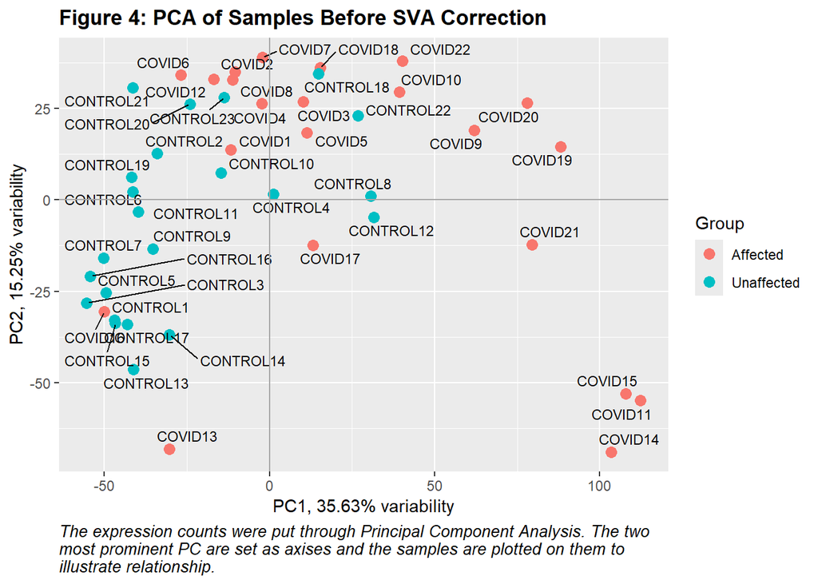

```
## Library size was 965005172 before SVA correction and is now 965500316 after SVA correction.
```

After conduction SVA correction, the data was visualized. The gene expression between samples are even (Figure 5). This can be partially explained by the samples’ expression counts normalization (Figure 6). To determine the correlation of the samples by calculating the interaction analysis by chi-square (IAC) for the 10% highest variable genes; there appears to be high correlation between all the samples within a group (previous COVID-19 infection or not) and lower correlation between groups (Figure 7). The hierarchical clustering of the samples do a line with groups (Figure 7). To further show the relationship between the samples, a principal component analysis (PCA) was done on the counts; the the statistical summary of the PCA results (Table 2) and the visualization (Figure 8) suggests that the relationship between the samples is based on group. These finding overall suggests that the batch effect has been removed from the samples.

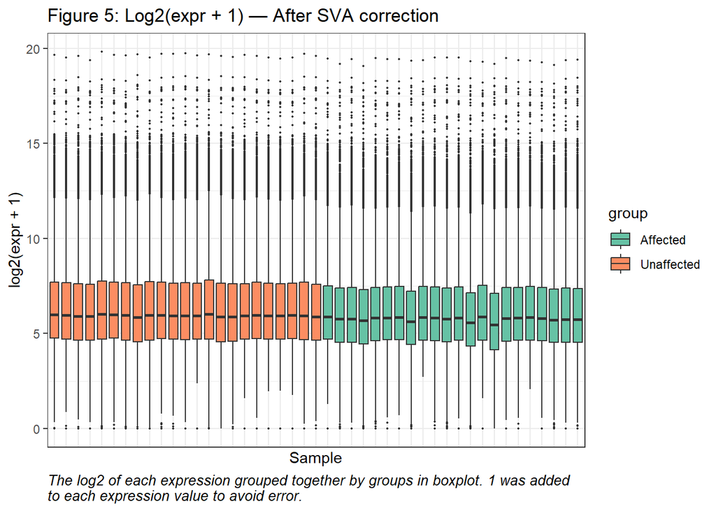

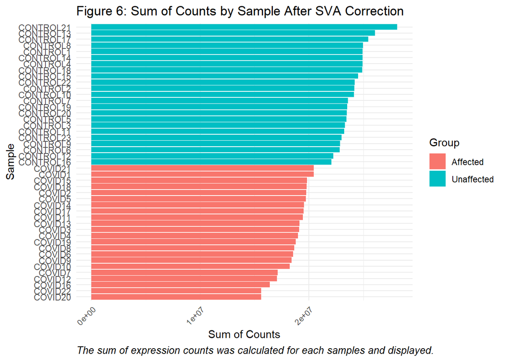

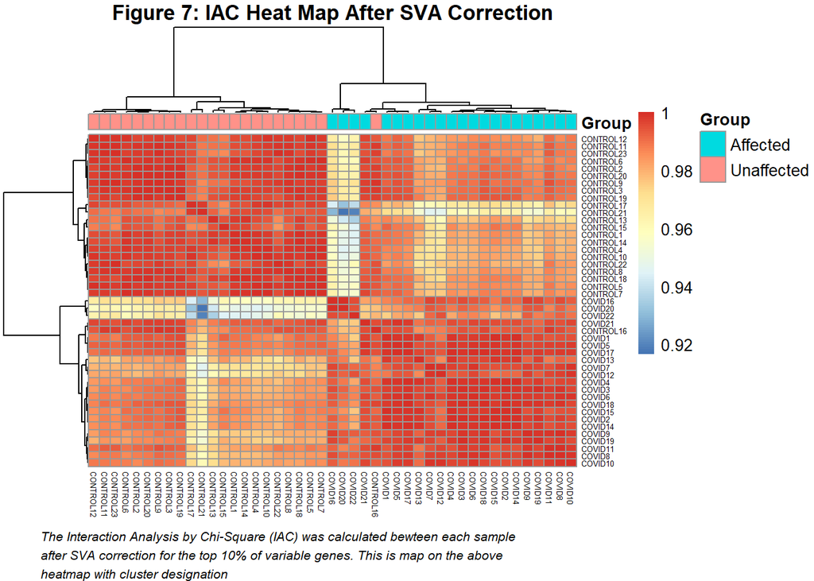

Table 2: Summary of PCA results After SVA correction

|  | PC1 | PC2 | PC3 | PC4 | PC5 |
| --- | --- | --- | --- | --- | --- |
| Standard deviation | 67.399 | 36.841 | 20.270 | 9.369 | 2.389 |
| Proportion of Variance | 0.709 | 0.212 | 0.064 | 0.014 | 0.001 |
| Cumulative Proportion | 0.709 | 0.920 | 0.985 | 0.998 | 0.999 |

**Note:** <sup>a</sup>*The expression counts were put through Principal Component Analysis. The results are summarized above.*

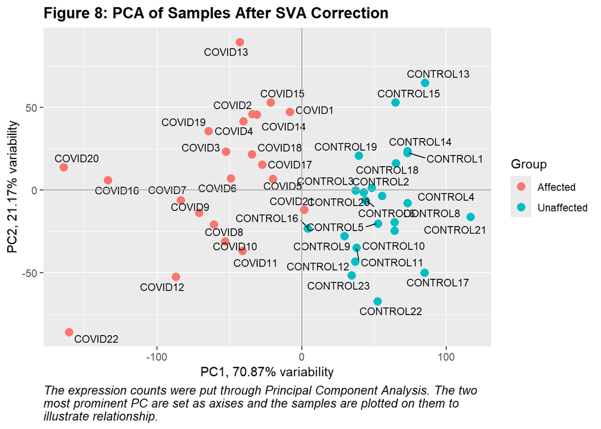

## Differential expression

After the expression counts have been normalized and the batch effect addressed, differential expression analysis commenced. The tags seem to follow the a common trend (Figure 9). Table 3 has an example of the count data being analyzed. A model was created that incorporated the age, sex, and if the patient had previously had COVID-19 then the data was fitted to a general linear model with this model. This model was analyzed with a likelihood-ratio test with previous COVID-19 infection being the coefficient. This was used to determine the tags of the data, the top 10 tags are displayed in table 4. The total tags and their directions are shown in table 5 and illustrated in figure 10. The most differential expressed genes are visually different between the people who have been affected with COVID-19 and not affected (Figure 11).

```
## Common dispersion is 0.1401425 for this data set.
```

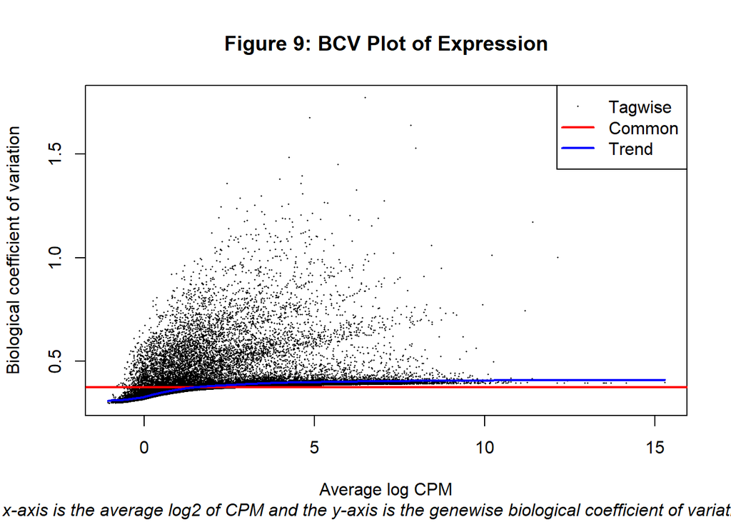

```
## integer(0)
```

Table 3: Example of Count per Million Data

|  | GSM5690952 | GSM5690953 | GSM5690954 | GSM5690955 | GSM5690956 | GSM5690957 | GSM5690958 | GSM5690959 | GSM5690960 | GSM5690961 |
| --- | --- | --- | --- | --- | --- | --- | --- | --- | --- | --- |
| ENST00000535434 | 0.525 | 0.030 | 0.000 | 0.194 | 0.608 | 0.290 | 0.007 | 0.000 | 0.000 | 0.313 |
| ENST00000515072 | 0.546 | 0.144 | 0.106 | 0.237 | 0.724 | 0.470 | 0.121 | 0.204 | 0.073 | 0.519 |
| ENST00000618265 | 0.886 | 0.744 | 1.323 | 0.882 | 0.977 | 1.284 | 0.720 | 0.799 | 0.972 | 0.954 |
| ENST00000638331 | 0.492 | 0.164 | 0.160 | 0.110 | 0.621 | 0.295 | 0.000 | 0.238 | 0.120 | 0.376 |
| ENST00000460368 | 0.969 | 0.931 | 1.666 | 0.917 | 0.925 | 1.237 | 0.647 | 0.915 | 1.169 | 0.815 |
| ENST00000513354 | 1.002 | 1.005 | 2.028 | 1.084 | 1.244 | 1.714 | 0.975 | 1.347 | 1.667 | 1.360 |

**Note:** <sup>a</sup>*The top 10 expression levels counts per million example.*

Table 4: Statitical Summary of the top 10 tags

|  | logFC | logCPM | LR | PValue | FDR |
| --- | --- | --- | --- | --- | --- |
| ENST00000535434 | -3.187 | -0.136 | 90.052 | 2.320e-21 | 1.487e-16 |
| ENST00000515072 | -2.453 | 0.033 | 83.529 | 6.280e-20 | 2.013e-15 |
| ENST00000618265 | 1.784 | -0.490 | 80.268 | 3.269e-19 | 6.985e-15 |
| ENST00000638331 | -2.770 | 0.142 | 77.263 | 1.496e-18 | 2.397e-14 |
| ENST00000460368 | 1.690 | -0.360 | 76.807 | 1.885e-18 | 2.417e-14 |
| ENST00000513354 | 2.023 | -0.048 | 74.692 | 5.501e-18 | 5.877e-14 |
| ENST00000463117 | 1.707 | -0.334 | 72.667 | 1.535e-17 | 1.406e-13 |
| ENST00000481106 | 1.634 | -0.197 | 69.679 | 6.979e-17 | 4.863e-13 |
| ENST00000367396 | 1.615 | 0.135 | 69.614 | 7.214e-17 | 4.863e-13 |
| ENST00000491602 | 2.101 | 1.385 | 69.514 | 7.587e-17 | 4.863e-13 |

**Note:** <sup>a</sup>*Statitical summary of top ten tags. logFC = logarithmic Fold Change, logCPM = log2 of copies per million, LR = likelihood ratio, and PValue = p-value, FDR = adjusted p-value.*

Table 5: Tags Counts

| Tags | Count |
| --- | --- |
| Down | 17654 |
| NotSig | 38360 |
| Up | 8085 |

<sup>a</sup> *A count of expression levels for tags relative to the no previous COVID-19 infection group to the previous COVID-19 group. The counts are of the expression that have relatively increase (Up), expression levels that have relatively decrease (Down), and have not changed (NotSig). The test for significants was done on the FDR values with a alpha value of 0.05*

```
## integer(0)
```

[figure not shown]

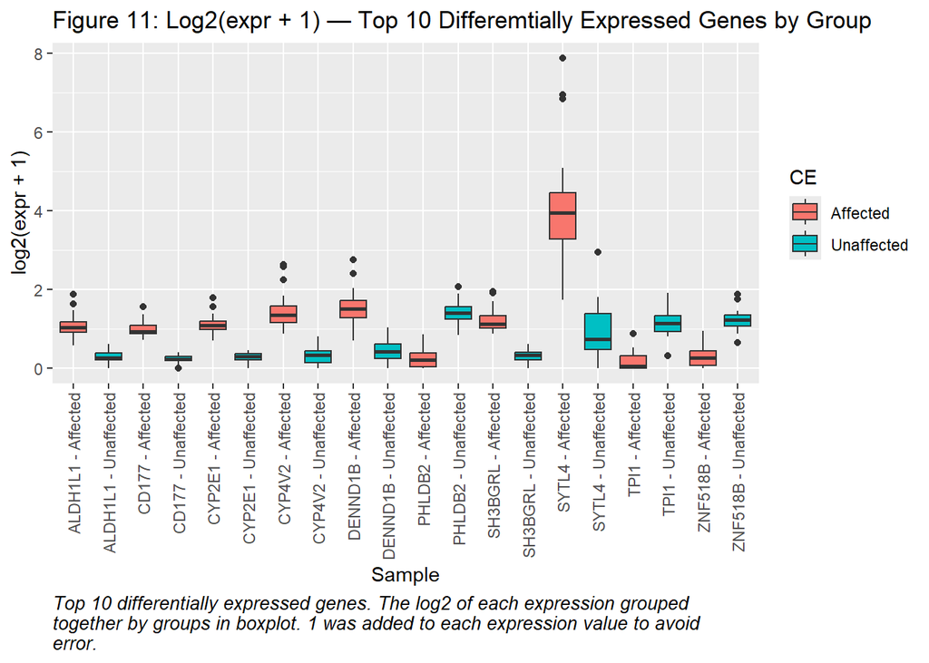

## Expression Visualization

The 9 most differential expressed protein coding genes visually appear to be distinct between individuals that have and have not been affected with COVID-19 (Figure 12). The relative expression of the top differential expressed genes are clearly based on the samples group (Figure 13). A volcano plot of expression reads shows that there are many signicanly expressed genes on a continuous scale (Figure 14). Some of the transcription read corresponded to the same gene, there average response was calculated and ploted (Figure 15), the results are similar to figure 14.

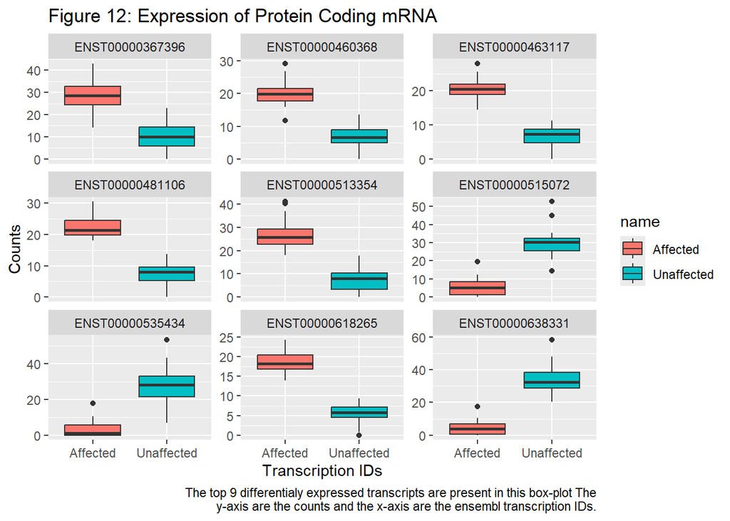

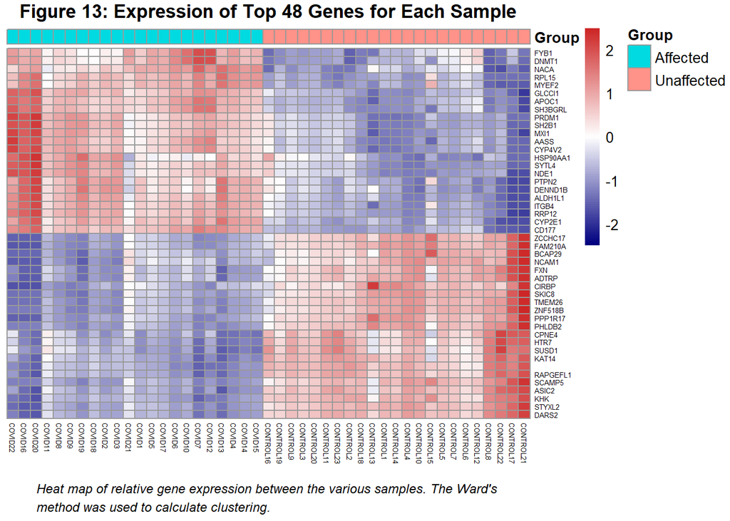

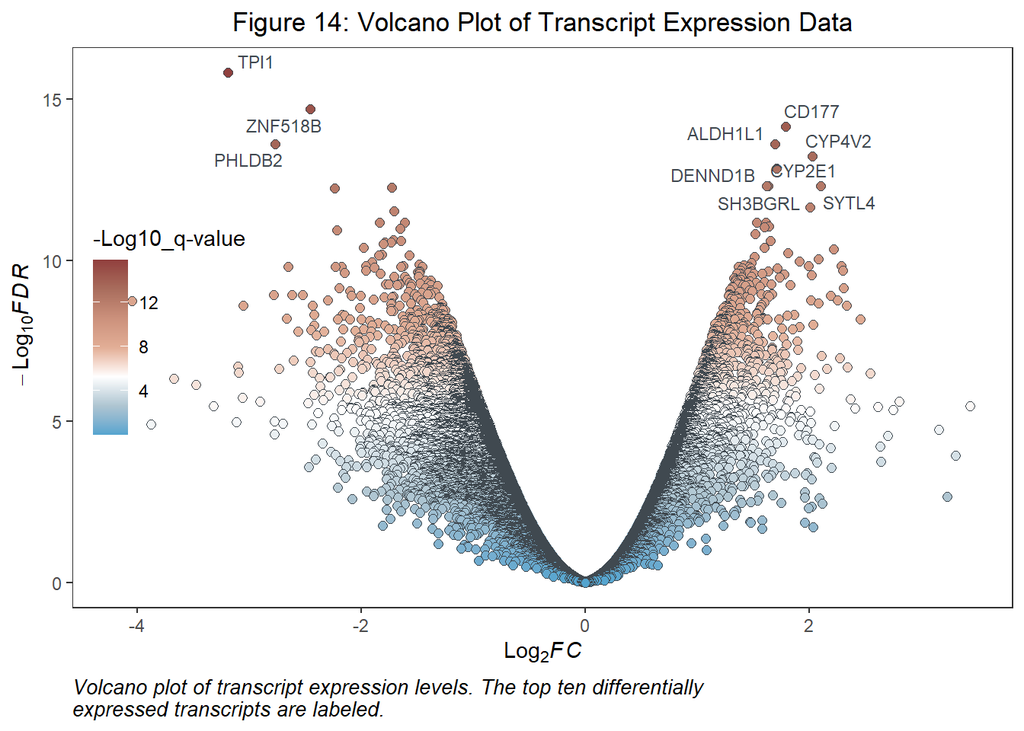

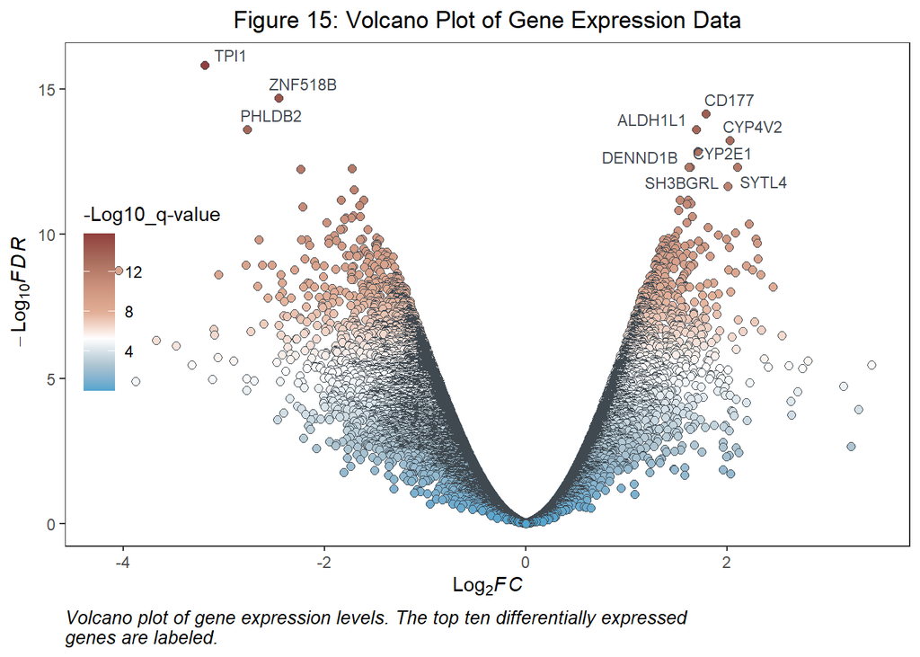

Table 6: Counts and Comparison between Source Study and Current Analysis

[output not shown]

<sup>a</sup> *The data for this analysis was sourced from a different study with the first auther is Dr. Maria Mavrikaki. This chart compares that study’s tag results with analysis tag results.*

## Functional Enrichment Analysis

### GSEA Plots

The GSEA plots (Figure 16 - 27) have the common trend of pathways associated with infection and immune response being enriched in frontal cortex samples that are from patients that previously had COVID-19. This suggest that even after infection the brain tissue is behaving like there is still an ongoing infection leading to possible health issues.

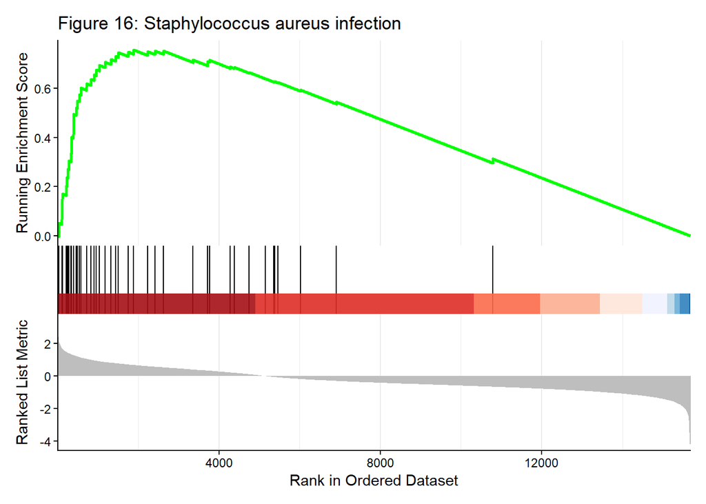

```
## Expression enrichment to reponses to staphylococcus aureus infection as illustrated by the GSEA plot.
```

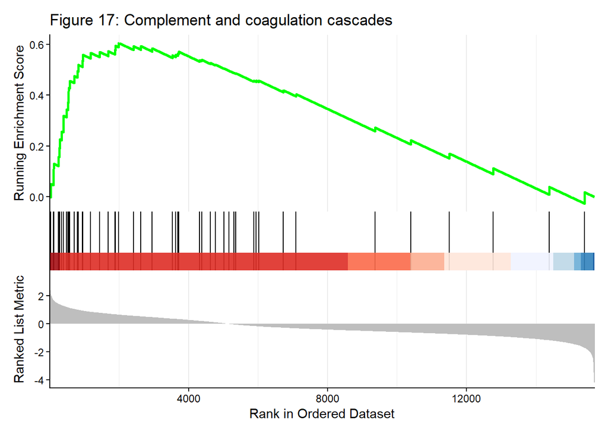

```
## Expression enrichment characterized in complement and coagulation cascades illustrated by the GSEA plot.
```

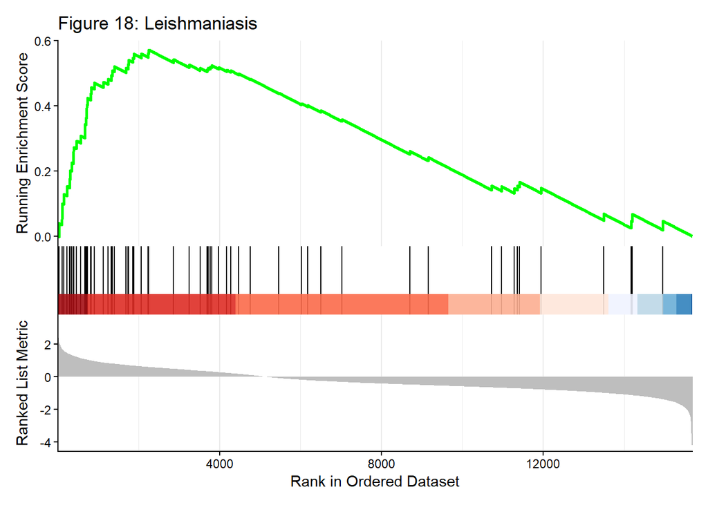

```
## Expression enrichment to reponses to leishmaniasis infection as illustrated by the GSEA plot.
```

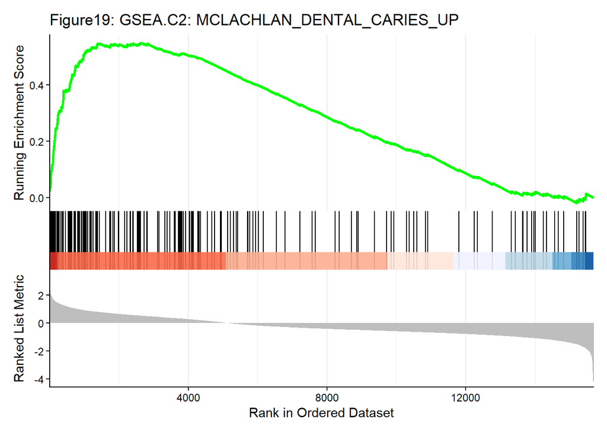

```
## 'Genes up-regulated in pulpal tissue extracted from carious teeth' (GSEA (2025)).
```

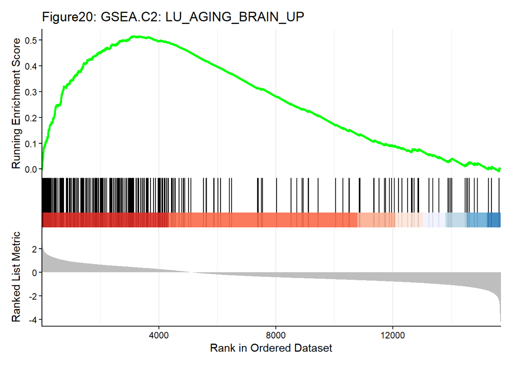

```
## 'Age up-regulated genes in the human frontal cortex' (GSEA (2025)).
```

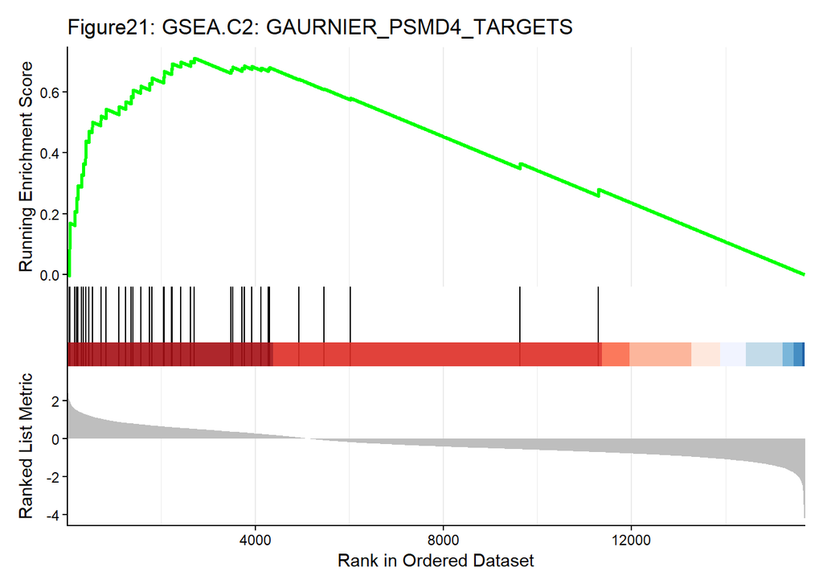

```
## 'Inflammatory cytokines, chemokines and their cognate receptors up-regulated in THP-1 cells (monocyte) after treatment with PSMD4' (GSEA (2025)).
```

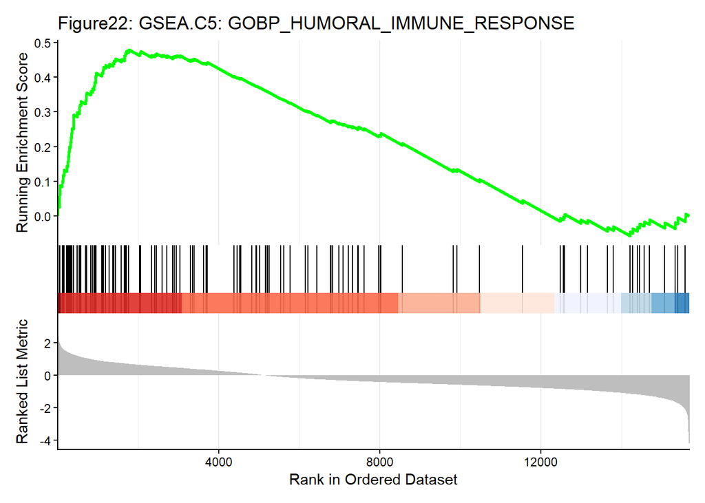

```
## 'An immune response mediated through a body fluid' (GSEA (2025)).
```

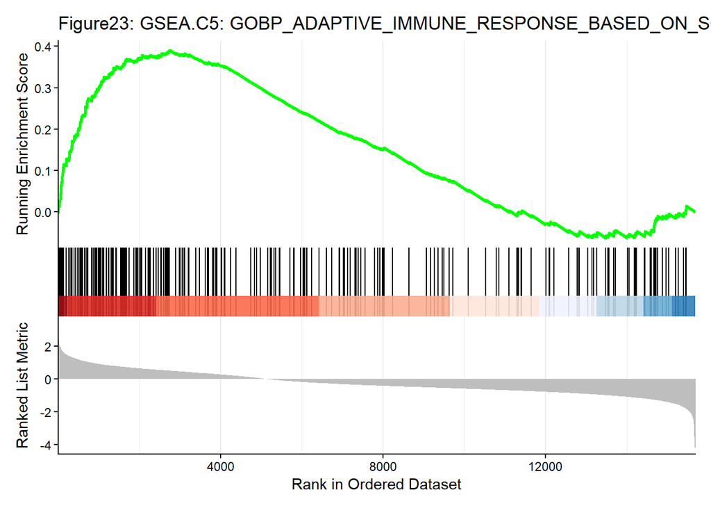

[output not shown]

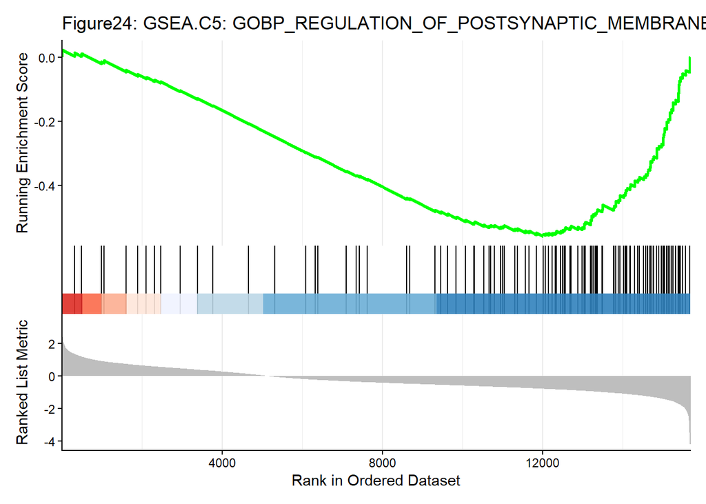

[output not shown]

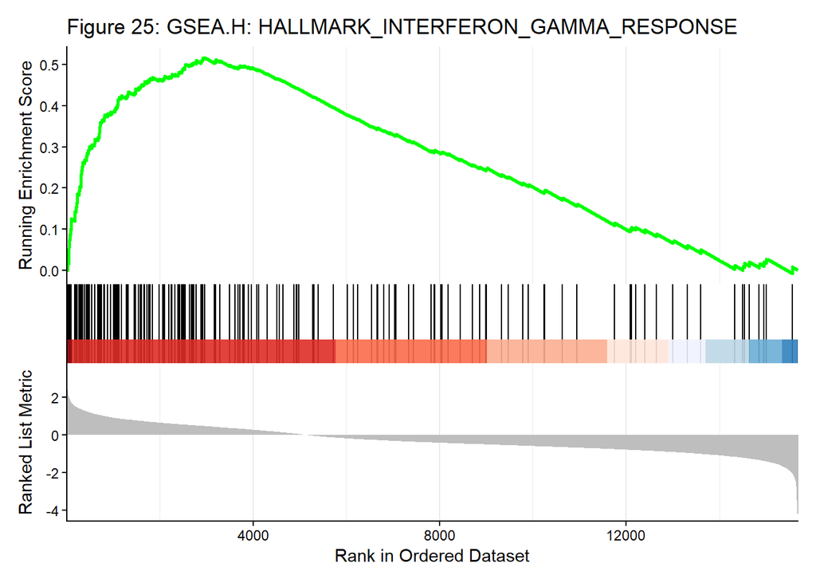

[output not shown]

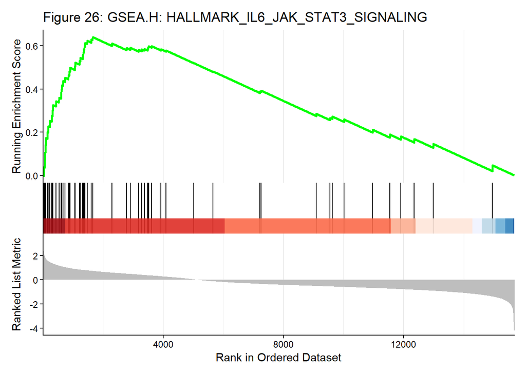

[output not shown]

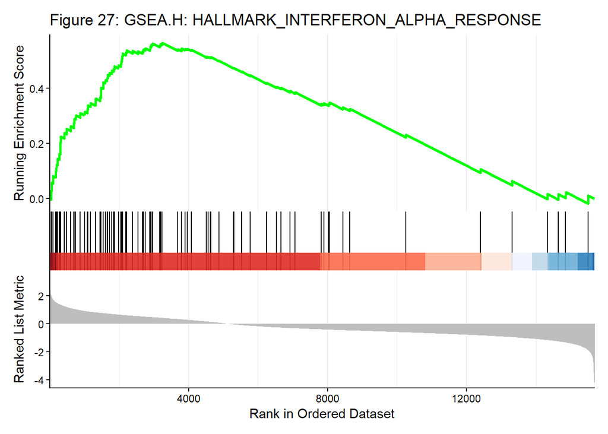

```
## 'Genes up-regulated in response to alpha interferon proteins' (GSEA (2025)).
```

### MSigDB gene sets

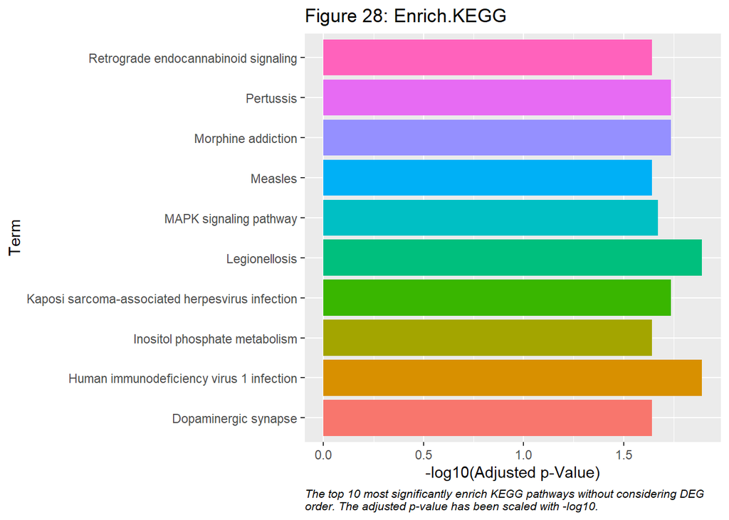

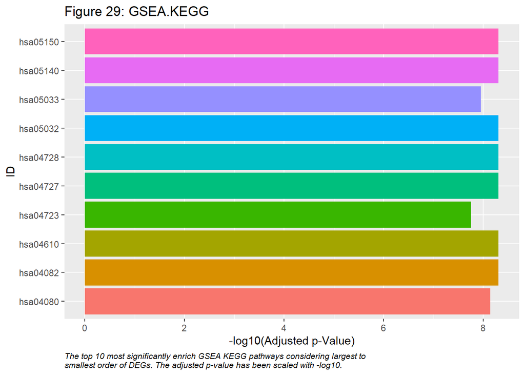

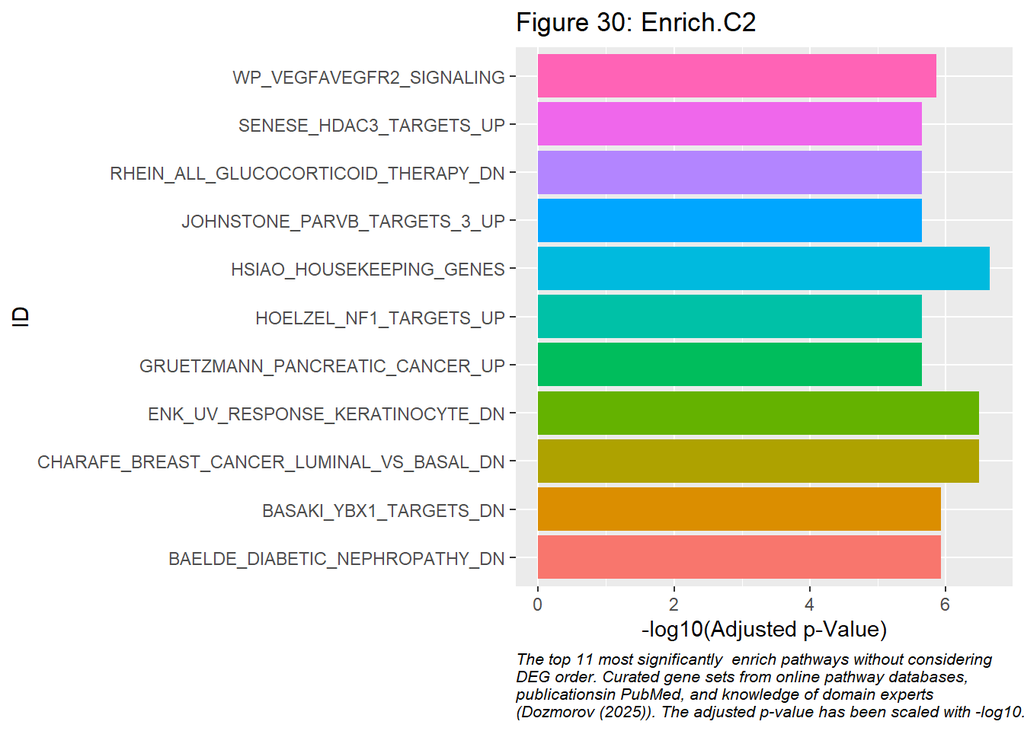

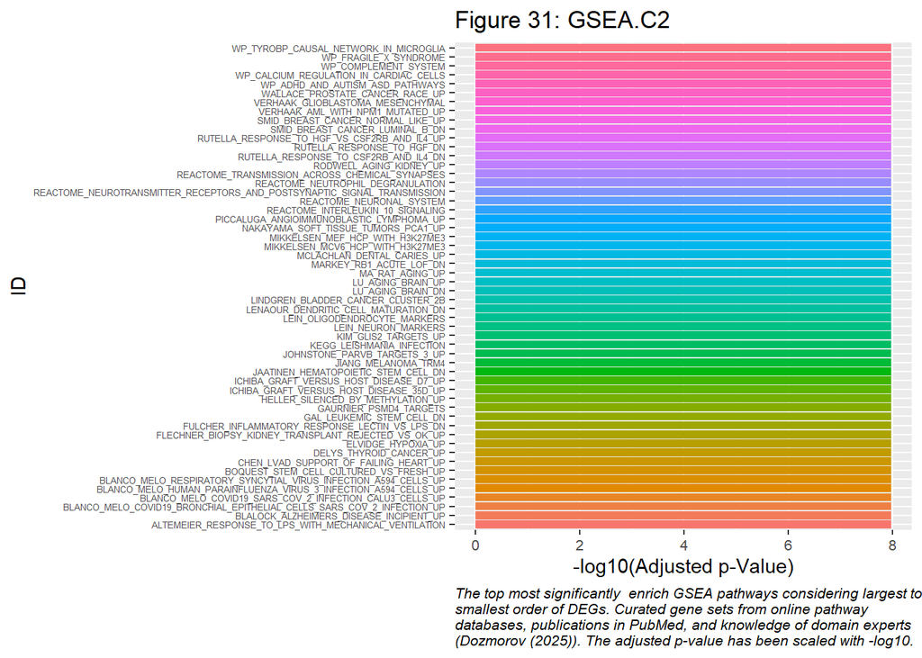